begin with loading package

```r
library(readr)
library(ggplot2)
library(scales)
library(dplyr)
```

Code for reading in the dataset and/or processing the data. BE CAREFUL, THIS IS WORKING WITH FRENCH DATE

```r
setwd("C:/Users/giffonev/Dropbox/TPR/reproducible-research-1")

activity <- read_csv("activity.csv", col_types = cols(steps = col_integer()))
activity$date <- as.Date(activity$date,format="%Y/%m/%d")
g <- ggplot(data=activity,aes(x=activity$date, y=activity$steps))
h <- ggplot(data=activity,aes(x=activity$interval, y=activity$steps))
activity$week <-



activity$week <- sapply(activity$date,weekdays)
 for (i in 1:length(activity$steps)) {
    if (activity$week[i] == "samedi") {
         activity$week[i] <- "weekend"
    } else if (activity$week[i] == "dimanche") {
         activity$week[i] <- "weekend"
    } else {
         activity$week[i] <- "weekday"
    }
 }
activity$week <- as.factor(activity$week)
```

Histogram of the total number of steps taken each day

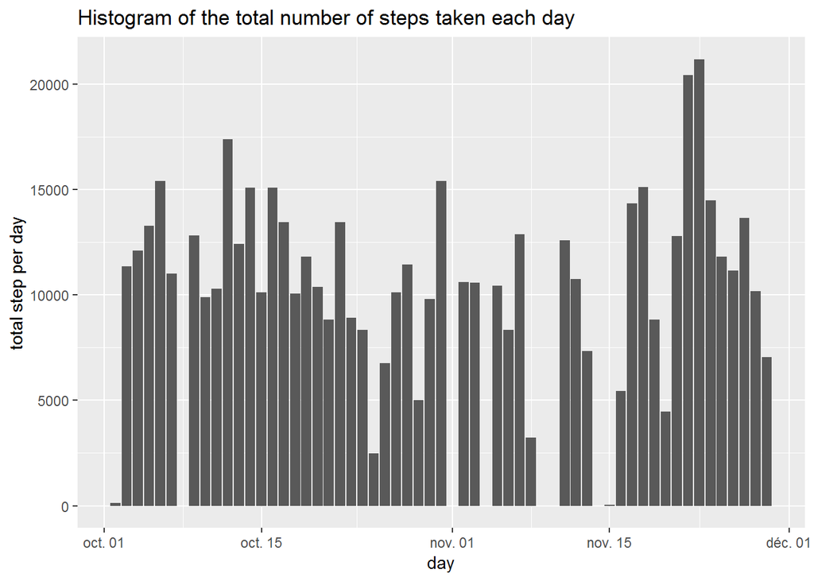

```r
g + geom_bar(stat = "identity") + labs(title = "Histogram of the total number of steps taken each day", x = "day", y = "total step per day")
```

Mean and median number of steps taken each day

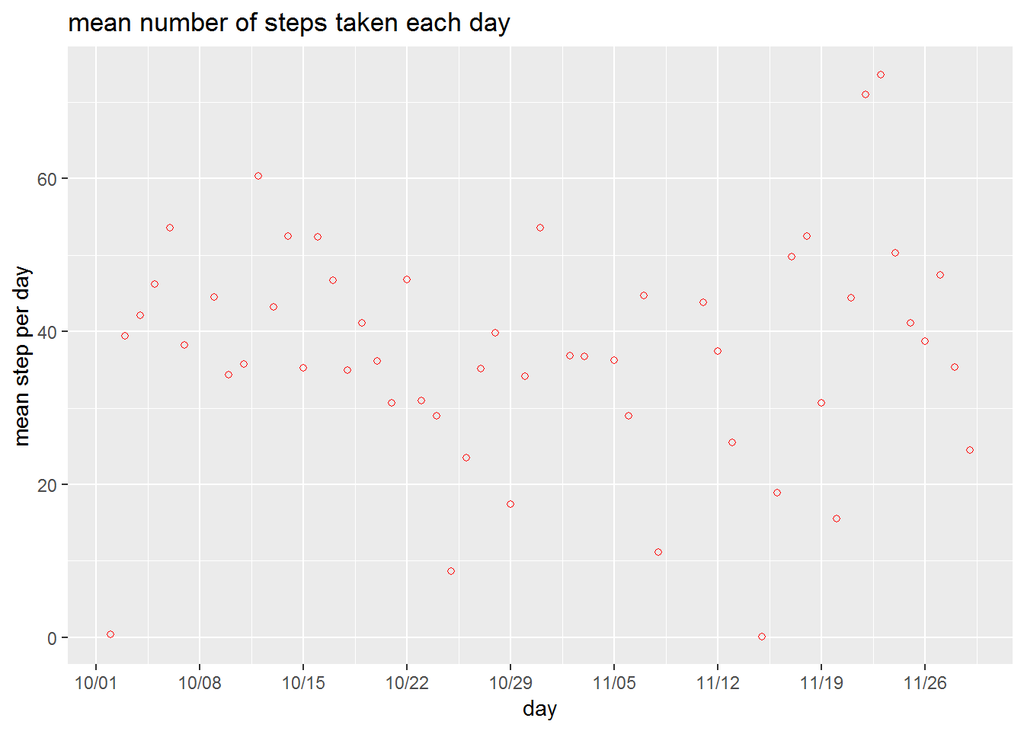

```r
g + stat_summary(fun.y=mean, geom="point", shape=1, size = 1.5, col = "red") + labs(title = "mean number of steps taken each day", x = "day", y = "mean step per day") + scale_x_date(labels = date_format("%m/%d"), breaks = "week")
```

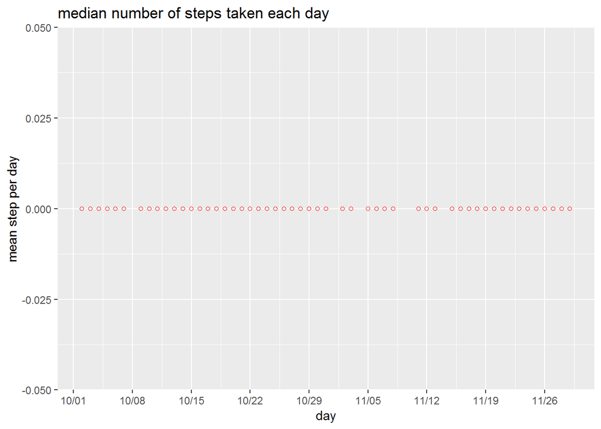

```r
g + stat_summary(fun.y=median, geom="point", shape=1, size = 1.5, col = "red") + labs(title = "median number of steps taken each day", x = "day", y = "mean step per day") + scale_x_date(labels = date_format("%m/%d"), breaks = "week")
```

Time series plot of the average number of steps taken

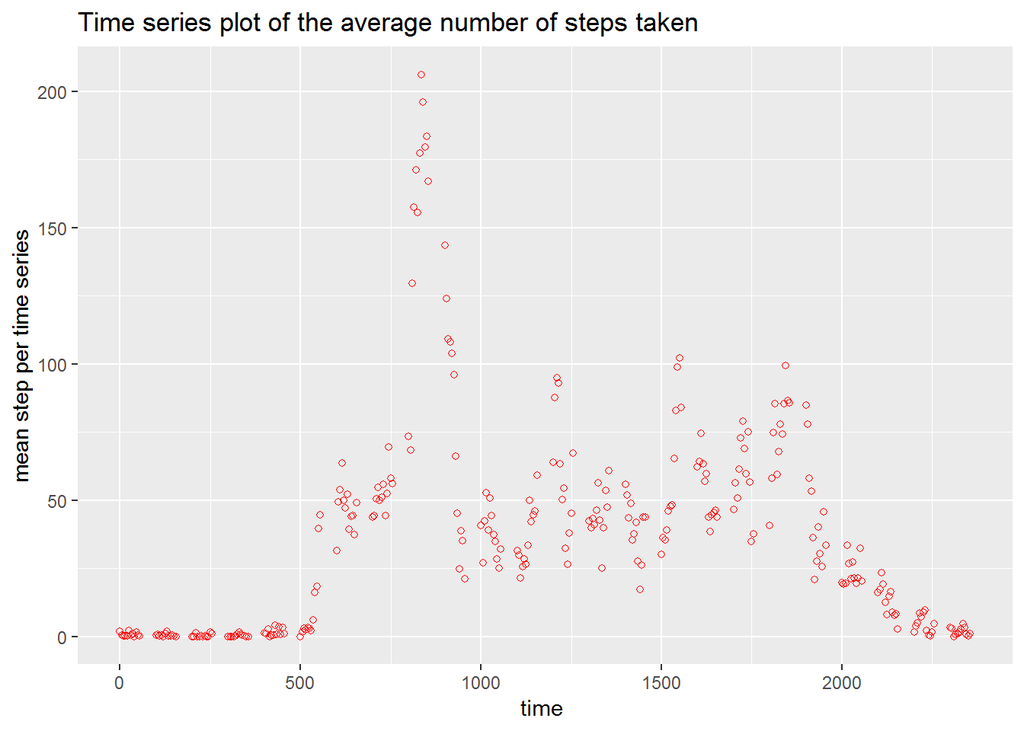

```r
h + stat_summary(fun.y=mean, geom="point", shape=1, size = 1.5, col = "red") + labs(title = "Time series plot of the average number of steps taken", x = "time ", y = "mean step per time series")
```

```r
test <- tapply(activity$steps,activity$interval,mean, na.rm=TRUE)
max(test)
```

```
## [1] 206.1698
```

Code to describe and show a strategy for imputing missing data

```r
#number of NA :
sum(is.na(activity$steps))
```

```
## [1] 2304
```

```r
#replacing NA with the mean :
activity$steps[is.na(activity$steps)] <- mean(activity$steps, na.rm  = TRUE)
sum(is.na(activity$steps))
```

```
## [1] 0
```

Histogram of the total number of steps taken each day after missing values are imputed

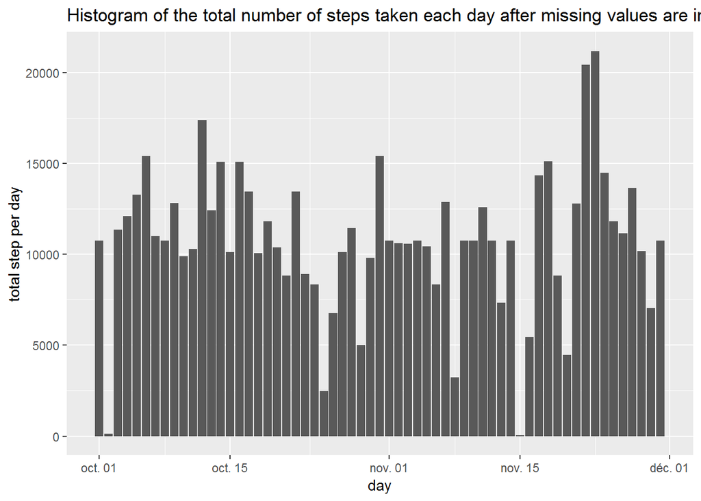

```r
j <- ggplot(data=activity,aes(x=activity$date, y=activity$steps))
j + geom_bar(stat = "identity") + labs(title = "Histogram of the total number of steps taken each day after missing values are imputed", x = "day", y = "total step per day")
```

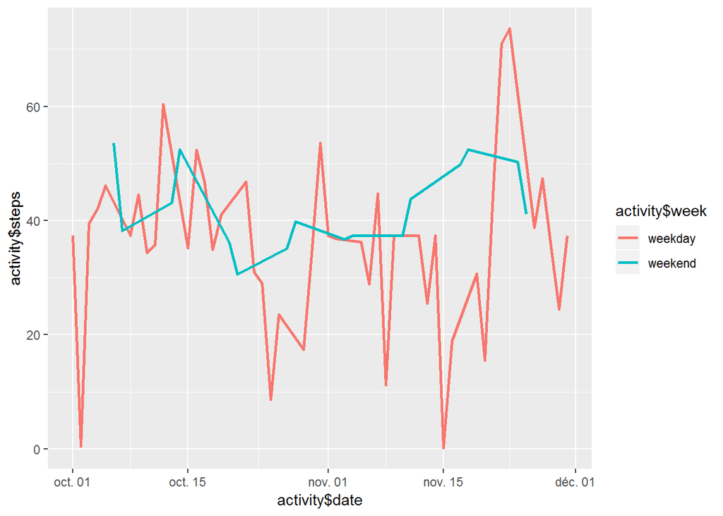

```r
k <- ggplot(data=activity,aes( x = activity$date, y=activity$steps, color = activity$week))
k + stat_summary(fun.y=mean, geom="line", size = 1)
```

All of the R code needed to reproduce the results (numbers, plots, etc.) in the report

setwd(“C:/Users/giffonev/Dropbox/TPR/reproducible-research-1”)

Histogram of the total number of steps taken each day

g + geom_bar(stat = “identity”) + labs(title = “Histogram of the total number of steps taken each day”, x = “day”, y = “total step per day”)

Mean and median number of steps taken each day

g + stat_summary(fun.y=mean, geom=“point”, shape=1, size = 1.5, col = “red”) + labs(title = “mean number of steps taken each day”, x = “day”, y = “mean step per day”) + scale_x_date(labels = date_format(“%m/%d”), breaks = “week”)

g + stat_summary(fun.y=median, geom=“point”, shape=1, size = 1.5, col = “red”) + labs(title = “median number of steps taken each day”, x = “day”, y = “mean step per day”) + scale_x_date(labels = date_format(“%m/%d”), breaks = “week”)

Time series plot of the average number of steps taken

h + stat_summary(fun.y=mean, geom=“point”, shape=1, size = 1.5, col = “red”) + labs(title = “Time series plot of the average number of steps taken”, x = “time”, y = “mean step per time series”)

Code to describe and show a strategy for imputing missing data

# number of NA :

sum(is.na(activity$steps))

# replacing NA with the mean :

Histogram of the total number of steps taken each day after missing values are imputed